# Exploration slides

## Loan Data Exploration

### By Muluneh

### Preliminary Wrangling

This document explores a dataset containing 113,937 loans with 81 variables on each loan, including loan amount, borrower rate (or interest rate), current loan status, borrower income, and many others.

## Data Gathering

|  | ListingKey | ListingNumber | ListingCreationDate | CreditGrade | Term | LoanStatus | ClosedDate | BorrowerAPR | BorrowerRate | LenderYield | ... | LP_ServiceFees | LP_CollectionFees | LP_GrossPrincipalLoss | LP_NetPrincipalLoss | LP_NonPrincipalRecoverypayments | PercentFunded | Recommendations | InvestmentFromFriendsCount | InvestmentFromFriendsAmount | Investors |
| --- | --- | --- | --- | --- | --- | --- | --- | --- | --- | --- | --- | --- | --- | --- | --- | --- | --- | --- | --- | --- | --- |
| 0 | 1021339766868145413AB3B | 193129 | 2007-08-26 19:09:29.263000000 | C | 36 | Completed | 2009-08-14 00:00:00 | 0.16516 | 0.1580 | 0.1380 | ... | -133.18 | 0.0 | 0.0 | 0.0 | 0.0 | 1.0 | 0 | 0 | 0.0 | 258 |
| 1 | 10273602499503308B223C1 | 1209647 | 2014-02-27 08:28:07.900000000 | NaN | 36 | Current | NaN | 0.12016 | 0.0920 | 0.0820 | ... | 0.00 | 0.0 | 0.0 | 0.0 | 0.0 | 1.0 | 0 | 0 | 0.0 | 1 |
| 2 | 0EE9337825851032864889A | 81716 | 2007-01-05 15:00:47.090000000 | HR | 36 | Completed | 2009-12-17 00:00:00 | 0.28269 | 0.2750 | 0.2400 | ... | -24.20 | 0.0 | 0.0 | 0.0 | 0.0 | 1.0 | 0 | 0 | 0.0 | 41 |
| 3 | 0EF5356002482715299901A | 658116 | 2012-10-22 11:02:35.010000000 | NaN | 36 | Current | NaN | 0.12528 | 0.0974 | 0.0874 | ... | -108.01 | 0.0 | 0.0 | 0.0 | 0.0 | 1.0 | 0 | 0 | 0.0 | 158 |
| 4 | 0F023589499656230C5E3E2 | 909464 | 2013-09-14 18:38:39.097000000 | NaN | 36 | Current | NaN | 0.24614 | 0.2085 | 0.1985 | ... | -60.27 | 0.0 | 0.0 | 0.0 | 0.0 | 1.0 | 0 | 0 | 0.0 | 20 |

5 rows × 81 columns

```
(113937, 81)
```

|  | ListingKey | ListingNumber | ListingCreationDate | CreditGrade | Term | LoanStatus | ClosedDate | BorrowerAPR | BorrowerRate | LenderYield | ... | LP_ServiceFees | LP_CollectionFees | LP_GrossPrincipalLoss | LP_NetPrincipalLoss | LP_NonPrincipalRecoverypayments | PercentFunded | Recommendations | InvestmentFromFriendsCount | InvestmentFromFriendsAmount | Investors |
| --- | --- | --- | --- | --- | --- | --- | --- | --- | --- | --- | --- | --- | --- | --- | --- | --- | --- | --- | --- | --- | --- |
| 0 | 1021339766868145413AB3B | 193129 | 2007-08-26 19:09:29.263000000 | C | 36 | Completed | 2009-08-14 00:00:00 | 0.16516 | 0.1580 | 0.1380 | ... | -133.18 | 0.0 | 0.0 | 0.0 | 0.0 | 1.0 | 0 | 0 | 0.0 | 258 |
| 1 | 10273602499503308B223C1 | 1209647 | 2014-02-27 08:28:07.900000000 | NaN | 36 | Current | NaN | 0.12016 | 0.0920 | 0.0820 | ... | 0.00 | 0.0 | 0.0 | 0.0 | 0.0 | 1.0 | 0 | 0 | 0.0 | 1 |
| 2 | 0EE9337825851032864889A | 81716 | 2007-01-05 15:00:47.090000000 | HR | 36 | Completed | 2009-12-17 00:00:00 | 0.28269 | 0.2750 | 0.2400 | ... | -24.20 | 0.0 | 0.0 | 0.0 | 0.0 | 1.0 | 0 | 0 | 0.0 | 41 |
| 3 | 0EF5356002482715299901A | 658116 | 2012-10-22 11:02:35.010000000 | NaN | 36 | Current | NaN | 0.12528 | 0.0974 | 0.0874 | ... | -108.01 | 0.0 | 0.0 | 0.0 | 0.0 | 1.0 | 0 | 0 | 0.0 | 158 |
| 4 | 0F023589499656230C5E3E2 | 909464 | 2013-09-14 18:38:39.097000000 | NaN | 36 | Current | NaN | 0.24614 | 0.2085 | 0.1985 | ... | -60.27 | 0.0 | 0.0 | 0.0 | 0.0 | 1.0 | 0 | 0 | 0.0 | 20 |

5 rows × 81 columns

```
(113937, 81)
```

```
<class 'pandas.core.frame.DataFrame'>
RangeIndex: 113937 entries, 0 to 113936
Data columns (total 81 columns):
 #   Column                               Non-Null Count   Dtype
---  ------                               --------------   -----
 0   ListingKey                           113937 non-null  object
 1   ListingNumber                        113937 non-null  int64
 2   ListingCreationDate                  113937 non-null  object
 3   CreditGrade                          28953 non-null   object
 4   Term                                 113937 non-null  int64
 5   LoanStatus                           113937 non-null  object
 6   ClosedDate                           55089 non-null   object
 7   BorrowerAPR                          113912 non-null  float64
 8   BorrowerRate                         113937 non-null  float64
 9   LenderYield                          113937 non-null  float64
```

[output cut: 73 more lines]

## Data Assessing and Cleaning

1. Choose some columns from the dataset which is interested for the analysis
2. Drop duplicated rows according to the datset description
3. Removed rows without ProsperRating
4. Fill in missing values of occupation and DebtToIncomeRatio
5. Remove the missed data columns
6. Datatype conversion

|  | ListingCreationDate | Term | LoanStatus | ClosedDate | BorrowerAPR | BorrowerRate | ProsperRating (numeric) | ProsperRating (Alpha) | Occupation | ProsperScore | ... | IncomeRange | DebtToIncomeRatio | ScorexChangeAtTimeOfListing | LoanOriginalAmount | LoanOriginationQuarter | TotalInquiries | MonthlyLoanPayment | InvestmentFromFriendsCount | InvestmentFromFriendsAmount | Investors |
| --- | --- | --- | --- | --- | --- | --- | --- | --- | --- | --- | --- | --- | --- | --- | --- | --- | --- | --- | --- | --- | --- |
| 113927 | 2008-04-30 21:25:19.670000000 | 36 | Completed | 2011-05-09 00:00:00 | 0.07469 | 0.0679 | NaN | NaN | Executive | NaN | ... | $100,000+ | 0.06 | 0.0 | 4292 | Q2 2008 | 9.0 | 132.11 | 0 | 0.0 | 194 |
| 113928 | 2011-06-06 19:02:44.443000000 | 36 | Completed | 2011-09-19 00:00:00 | 0.22362 | 0.1899 | 4.0 | C | Other | 6.0 | ... | $25,000-49,999 | 0.27 | 8.0 | 2000 | Q2 2011 | 2.0 | 73.30 | 0 | 0.0 | 25 |
| 113929 | 2013-07-06 17:40:01.657000000 | 36 | Completed | 2014-02-07 00:00:00 | 0.30285 | 0.2639 | 2.0 | E | Accountant/CPA | 3.0 | ... | $50,000-74,999 | 0.05 | NaN | 2500 | Q3 2013 | 19.0 | 101.25 | 0 | 0.0 | 26 |
| 113930 | 2013-07-08 10:24:49.700000000 | 36 | Current | NaN | 0.20053 | 0.1639 | 5.0 | B | Professional | 6.0 | ... | $75,000-99,999 | 0.20 | -73.0 | 3000 | Q3 2013 | 7.0 | 106.05 | 0 | 0.0 | 52 |
| 113931 | 2014-01-16 20:13:08.040000000 | 60 | Current | NaN | 0.15016 | 0.1274 | 5.0 | B | Analyst | 6.0 | ... | $75,000-99,999 | 0.28 | NaN | 25000 | Q1 2014 | 8.0 | 565.50 | 0 | 0.0 | 1 |
| 113932 | 2013-04-14 05:55:02.663000000 | 36 | Current | NaN | 0.22354 | 0.1864 | 4.0 | C | Food Service Management | 5.0 | ... | $50,000-74,999 | 0.13 | NaN | 10000 | Q2 2013 | 0.0 | 364.74 | 0 | 0.0 | 1 |
| 113933 | 2011-11-03 20:42:55.333000000 | 36 | FinalPaymentInProgress | NaN | 0.13220 | 0.1110 | 6.0 | A | Professional | 8.0 | ... | $75,000-99,999 | 0.11 | -26.0 | 2000 | Q4 2011 | 4.0 | 65.57 | 0 | 0.0 | 22 |
| 113934 | 2013-12-13 05:49:12.703000000 | 60 | Current | NaN | 0.23984 | 0.2150 | 3.0 | D | Other | 3.0 | ... | $25,000-49,999 | 0.51 | NaN | 10000 | Q4 2013 | 2.0 | 273.35 | 0 | 0.0 | 119 |
| 113935 | 2011-11-14 13:18:26.597000000 | 60 | Completed | 2013-08-13 00:00:00 | 0.28408 | 0.2605 | 4.0 | C | Food Service | 5.0 | ... | $25,000-49,999 | 0.48 | -4.0 | 15000 | Q4 2011 | 4.0 | 449.55 | 0 | 0.0 | 274 |
| 113936 | 2014-01-15 09:27:37.657000000 | 36 | Current | NaN | 0.13189 | 0.1039 | 6.0 | A | Professor | 7.0 | ... | $50,000-74,999 | 0.23 | NaN | 2000 | Q1 2014 | 1.0 | 64.90 | 0 | 0.0 | 1 |

10 rows × 23 columns

```
(113937, 23)
```

```
<class 'pandas.core.frame.DataFrame'>
RangeIndex: 113937 entries, 0 to 113936
Data columns (total 23 columns):
 #   Column                       Non-Null Count   Dtype
---  ------                       --------------   -----
 0   ListingCreationDate          113937 non-null  object
 1   Term                         113937 non-null  int64
 2   LoanStatus                   113937 non-null  object
 3   ClosedDate                   55089 non-null   object
 4   BorrowerAPR                  113912 non-null  float64
 5   BorrowerRate                 113937 non-null  float64
 6   ProsperRating (numeric)      84853 non-null   float64
 7   ProsperRating (Alpha)        84853 non-null   object
 8   Occupation                   110349 non-null  object
 9   ProsperScore                 84853 non-null   float64
 10  EmploymentStatus             111682 non-null  object
 11  CreditScoreRangeLower        113346 non-null  float64
 12  CreditScoreRangeUpper        113346 non-null  float64
 13  IncomeRange                  113937 non-null  object
 14  DebtToIncomeRatio            105383 non-null  float64
 15  ScorexChangeAtTimeOfListing  18928 non-null   float64
 16  LoanOriginalAmount           113937 non-null  int64
 17  LoanOriginationQuarter       113937 non-null  object
 18  TotalInquiries               112778 non-null  float64
 19  MonthlyLoanPayment           113937 non-null  float64
 20  InvestmentFromFriendsCount   113937 non-null  int64
 21  InvestmentFromFriendsAmount  113937 non-null  float64
 22  Investors                    113937 non-null  int64
dtypes: float64(11), int64(4), object(8)
memory usage: 20.0+ MB
```

```
<class 'pandas.core.frame.DataFrame'>
Int64Index: 113937 entries, 0 to 113936
Data columns (total 23 columns):
 #   Column                       Non-Null Count   Dtype
---  ------                       --------------   -----
 0   ListingCreationDate          113937 non-null  object
 1   Term                         113937 non-null  int64
 2   LoanStatus                   113937 non-null  object
 3   ClosedDate                   55089 non-null   object
 4   BorrowerAPR                  113912 non-null  float64
 5   BorrowerRate                 113937 non-null  float64
 6   ProsperRating (numeric)      84853 non-null   float64
 7   ProsperRating (Alpha)        84853 non-null   object
 8   Occupation                   110349 non-null  object
 9   ProsperScore                 84853 non-null   float64
 10  EmploymentStatus             111682 non-null  object
 11  CreditScoreRangeLower        113346 non-null  float64
 12  CreditScoreRangeUpper        113346 non-null  float64
 13  IncomeRange                  113937 non-null  object
 14  DebtToIncomeRatio            105383 non-null  float64
 15  ScorexChangeAtTimeOfListing  18928 non-null   float64
 16  LoanOriginalAmount           113937 non-null  int64
 17  LoanOriginationQuarter       113937 non-null  object
 18  TotalInquiries               112778 non-null  float64
 19  MonthlyLoanPayment           113937 non-null  float64
 20  InvestmentFromFriendsCount   113937 non-null  int64
 21  InvestmentFromFriendsAmount  113937 non-null  float64
 22  Investors                    113937 non-null  int64
dtypes: float64(11), int64(4), object(8)
memory usage: 20.9+ MB
```

```
<class 'pandas.core.frame.DataFrame'>
Int64Index: 84853 entries, 1 to 113936
Data columns (total 23 columns):
 #   Column                       Non-Null Count  Dtype
---  ------                       --------------  -----
 0   ListingCreationDate          84853 non-null  object
 1   Term                         84853 non-null  int64
 2   LoanStatus                   84853 non-null  object
 3   ClosedDate                   26005 non-null  object
 4   BorrowerAPR                  84853 non-null  float64
 5   BorrowerRate                 84853 non-null  float64
 6   ProsperRating (numeric)      84853 non-null  float64
 7   ProsperRating (Alpha)        84853 non-null  object
 8   Occupation                   84853 non-null  object
 9   ProsperScore                 84853 non-null  float64
 10  EmploymentStatus             84853 non-null  object
 11  CreditScoreRangeLower        84853 non-null  float64
 12  CreditScoreRangeUpper        84853 non-null  float64
 13  IncomeRange                  84853 non-null  object
 14  DebtToIncomeRatio            77557 non-null  float64
 15  ScorexChangeAtTimeOfListing  16642 non-null  float64
 16  LoanOriginalAmount           84853 non-null  int64
 17  LoanOriginationQuarter       84853 non-null  object
 18  TotalInquiries               84853 non-null  float64
 19  MonthlyLoanPayment           84853 non-null  float64
 20  InvestmentFromFriendsCount   84853 non-null  int64
 21  InvestmentFromFriendsAmount  84853 non-null  float64
 22  Investors                    84853 non-null  int64
dtypes: float64(11), int64(4), object(8)
memory usage: 15.5+ MB
```

```
1         2014-02-27
3         2012-10-22
4         2013-09-14
5         2013-12-14
6         2013-04-12
             ...
113932    2013-04-14
113933    2011-11-03
113934    2013-12-13
113935    2011-11-14
113936    2014-01-15
Name: ListingCreationDate, Length: 84853, dtype: object
```

```
<class 'pandas.core.frame.DataFrame'>
Int64Index: 84853 entries, 1 to 113936
Data columns (total 23 columns):
 #   Column                       Non-Null Count  Dtype
---  ------                       --------------  -----
 0   ListingCreationDate          84853 non-null  object
 1   Term                         84853 non-null  int64
 2   LoanStatus                   84853 non-null  object
 3   ClosedDate                   26005 non-null  object
 4   BorrowerAPR                  84853 non-null  float64
 5   BorrowerRate                 84853 non-null  float64
 6   ProsperRating (numeric)      84853 non-null  float64
 7   ProsperRating (Alpha)        84853 non-null  object
 8   Occupation                   84853 non-null  object
 9   ProsperScore                 84853 non-null  float64
 10  EmploymentStatus             84853 non-null  object
 11  CreditScoreRangeLower        84853 non-null  float64
 12  CreditScoreRangeUpper        84853 non-null  float64
 13  IncomeRange                  84853 non-null  object
 14  DebtToIncomeRatio            77557 non-null  float64
 15  ScorexChangeAtTimeOfListing  16642 non-null  float64
 16  LoanOriginalAmount           84853 non-null  int64
 17  LoanOriginationQuarter       84853 non-null  object
 18  TotalInquiries               84853 non-null  float64
 19  MonthlyLoanPayment           84853 non-null  float64
 20  InvestmentFromFriendsCount   84853 non-null  int64
 21  InvestmentFromFriendsAmount  84853 non-null  float64
 22  Investors                    84853 non-null  int64
dtypes: float64(11), int64(4), object(8)
memory usage: 15.5+ MB
```

|  | ListingCreationDate | Term | LoanStatus | ClosedDate | BorrowerAPR | BorrowerRate | ProsperRating (numeric) | ProsperRating (Alpha) | Occupation | ProsperScore | ... | IncomeRange | DebtToIncomeRatio | ScorexChangeAtTimeOfListing | LoanOriginalAmount | LoanOriginationQuarter | TotalInquiries | MonthlyLoanPayment | InvestmentFromFriendsCount | InvestmentFromFriendsAmount | Investors |
| --- | --- | --- | --- | --- | --- | --- | --- | --- | --- | --- | --- | --- | --- | --- | --- | --- | --- | --- | --- | --- | --- |
| 1 | 2014-02-27 | 36 | Current | NaN | 0.12016 | 0.0920 | 6.0 | A | Professional | 7.0 | ... | $50,000-74,999 | 0.18 | NaN | 10000 | Q1 2014 | 5.0 | 318.93 | 0 | 0.0 | 1 |
| 3 | 2012-10-22 | 36 | Current | NaN | 0.12528 | 0.0974 | 6.0 | A | Skilled Labor | 9.0 | ... | $25,000-49,999 | 0.15 | NaN | 10000 | Q4 2012 | 1.0 | 321.45 | 0 | 0.0 | 158 |
| 4 | 2013-09-14 | 36 | Current | NaN | 0.24614 | 0.2085 | 3.0 | D | Executive | 4.0 | ... | $100,000+ | 0.26 | NaN | 15000 | Q3 2013 | 9.0 | 563.97 | 0 | 0.0 | 20 |
| 5 | 2013-12-14 | 60 | Current | NaN | 0.15425 | 0.1314 | 5.0 | B | Professional | 10.0 | ... | $100,000+ | 0.36 | NaN | 15000 | Q4 2013 | 2.0 | 342.37 | 0 | 0.0 | 1 |
| 6 | 2013-04-12 | 36 | Current | NaN | 0.31032 | 0.2712 | 2.0 | E | Sales - Retail | 2.0 | ... | $25,000-49,999 | 0.27 | NaN | 3000 | Q2 2013 | 0.0 | 122.67 | 0 | 0.0 | 1 |

5 rows × 23 columns

```
<class 'pandas.core.frame.DataFrame'>
Int64Index: 84853 entries, 1 to 113936
Data columns (total 23 columns):
 #   Column                       Non-Null Count  Dtype
---  ------                       --------------  -----
 0   ListingCreationDate          84853 non-null  object
 1   Term                         84853 non-null  int64
 2   LoanStatus                   84853 non-null  object
 3   ClosedDate                   26005 non-null  object
 4   BorrowerAPR                  84853 non-null  float64
 5   BorrowerRate                 84853 non-null  float64
 6   ProsperRating (numeric)      84853 non-null  float64
 7   ProsperRating (Alpha)        84853 non-null  object
 8   Occupation                   84853 non-null  object
 9   ProsperScore                 84853 non-null  float64
 10  EmploymentStatus             84853 non-null  object
 11  CreditScoreRangeLower        84853 non-null  float64
 12  CreditScoreRangeUpper        84853 non-null  float64
 13  IncomeRange                  84853 non-null  object
 14  DebtToIncomeRatio            84853 non-null  float64
 15  ScorexChangeAtTimeOfListing  16642 non-null  float64
 16  LoanOriginalAmount           84853 non-null  int64
 17  LoanOriginationQuarter       84853 non-null  object
 18  TotalInquiries               84853 non-null  float64
 19  MonthlyLoanPayment           84853 non-null  float64
 20  InvestmentFromFriendsCount   84853 non-null  int64
 21  InvestmentFromFriendsAmount  84853 non-null  float64
 22  Investors                    84853 non-null  int64
dtypes: float64(11), int64(4), object(8)
memory usage: 15.5+ MB
```

```
<class 'pandas.core.frame.DataFrame'>
Int64Index: 84853 entries, 1 to 113936
Data columns (total 21 columns):
 #   Column                       Non-Null Count  Dtype
---  ------                       --------------  -----
 0   ListingCreationDate          84853 non-null  object
 1   Term                         84853 non-null  object
 2   LoanStatus                   84853 non-null  object
 3   BorrowerAPR                  84853 non-null  float64
 4   BorrowerRate                 84853 non-null  float64
 5   ProsperRating (numeric)      84853 non-null  float64
 6   ProsperRating (Alpha)        84853 non-null  object
 7   Occupation                   84853 non-null  object
 8   ProsperScore                 84853 non-null  float64
 9   EmploymentStatus             84853 non-null  object
 10  CreditScoreRangeLower        84853 non-null  float64
 11  CreditScoreRangeUpper        84853 non-null  float64
 12  IncomeRange                  84853 non-null  object
 13  DebtToIncomeRatio            84853 non-null  float64
 14  LoanOriginalAmount           84853 non-null  int64
 15  LoanOriginationQuarter       84853 non-null  object
 16  TotalInquiries               84853 non-null  float64
 17  MonthlyLoanPayment           84853 non-null  float64
 18  InvestmentFromFriendsCount   84853 non-null  int64
 19  InvestmentFromFriendsAmount  84853 non-null  float64
 20  Investors                    84853 non-null  int64
dtypes: float64(10), int64(3), object(8)
memory usage: 14.2+ MB
```

```
(84853, 21)
```

```
['ListingCreationDate',
 'Term',
 'LoanStatus',
 'BorrowerAPR',
 'BorrowerRate',
 'ProsperRating (numeric)',
 'ProsperRating (Alpha)',
 'Occupation',
 'ProsperScore',
 'EmploymentStatus',
 'CreditScoreRangeLower',
 'CreditScoreRangeUpper',
 'IncomeRange',
 'DebtToIncomeRatio',
 'LoanOriginalAmount',
 'LoanOriginationQuarter',
 'TotalInquiries',
 'MonthlyLoanPayment',
 'InvestmentFromFriendsCount',
 'InvestmentFromFriendsAmount',
 'Investors']
```

```
1          Employed
3          Employed
4          Employed
5          Employed
6          Employed
            ...
113932     Employed
113933     Employed
113934     Employed
113935    Full-time
113936     Employed
Name: EmploymentStatus, Length: 84853, dtype: object
```

### Exploratory Data Analysis

#### What is/are the main feature(s) of interest in the dataset?

1. What factors affects the lone outcome status.
2. What affects the borrower's Annual Percentage Rate (APR) rate.
3. Are the difference between loan depending on how large the origional loan amount was

### What features in the dataset do you think will help support your investigation into your feature(s) of interest?

In the dataset their are many features to explore, I suspect the following borrower features will have the largest effect on the performance of the loan/dataset:

1. **Term** - The length of the loan expressed in months..
2. **BorrowerAPR** - The Borrower's Annual Percentage Rate (APR) for the loan.
3. **ProsperRating (numeric)** - The Prosper Rating assigned at the time the listing was created: 0 - N/A, 1 - HR, 2 - E, 3 - D, 4 - C, 5 - B, 6 - A, 7 - AA. Applicable for loans originated after July 2009.
4. **LoanStatus** - The current status of the loan: Cancelled, Chargedoff, Completed, Current, Defaulted, FinalPaymentInProgress, PastDue. The PastDue status will be accompanied by a delinquency bucket.

### Univariate Exploration

Let's start by looking at the distribution of the main variable of interest: borrower APR.

|  | BorrowerAPR | BorrowerRate | ProsperRating (numeric) | ProsperScore | CreditScoreRangeLower | CreditScoreRangeUpper | DebtToIncomeRatio | LoanOriginalAmount | TotalInquiries | MonthlyLoanPayment | InvestmentFromFriendsCount | InvestmentFromFriendsAmount | Investors |
| --- | --- | --- | --- | --- | --- | --- | --- | --- | --- | --- | --- | --- | --- |
| count | 84853.000000 | 84853.000000 | 84853.000000 | 84853.000000 | 84853.000000 | 84853.000000 | 84853.000000 | 84853.000000 | 84853.000000 | 84853.000000 | 84853.000000 | 84853.000000 | 84853.000000 |
| mean | 0.226658 | 0.196022 | 4.072243 | 5.950067 | 699.390240 | 718.390240 | 0.258752 | 9083.440515 | 4.290396 | 291.930720 | 0.008049 | 4.315558 | 68.264669 |
| std | 0.079916 | 0.074631 | 1.673227 | 2.376501 | 47.095937 | 47.095937 | 0.304333 | 6287.860058 | 3.827574 | 186.678314 | 0.109721 | 117.005989 | 95.195831 |
| min | 0.045830 | 0.040000 | 1.000000 | 1.000000 | 600.000000 | 619.000000 | 0.000000 | 1000.000000 | 0.000000 | 0.000000 | 0.000000 | 0.000000 | 1.000000 |
| 25% | 0.163280 | 0.135900 | 3.000000 | 4.000000 | 660.000000 | 679.000000 | 0.160000 | 4000.000000 | 2.000000 | 157.330000 | 0.000000 | 0.000000 | 1.000000 |
| 50% | 0.219450 | 0.187500 | 4.000000 | 6.000000 | 700.000000 | 719.000000 | 0.240000 | 7500.000000 | 3.000000 | 251.940000 | 0.000000 | 0.000000 | 32.000000 |
| 75% | 0.292540 | 0.257400 | 5.000000 | 8.000000 | 720.000000 | 739.000000 | 0.310000 | 13500.000000 | 6.000000 | 388.350000 | 0.000000 | 0.000000 | 97.000000 |
| max | 0.423950 | 0.360000 | 7.000000 | 11.000000 | 880.000000 | 899.000000 | 10.010000 | 35000.000000 | 78.000000 | 2251.510000 | 9.000000 | 11000.000000 | 1189.000000 |

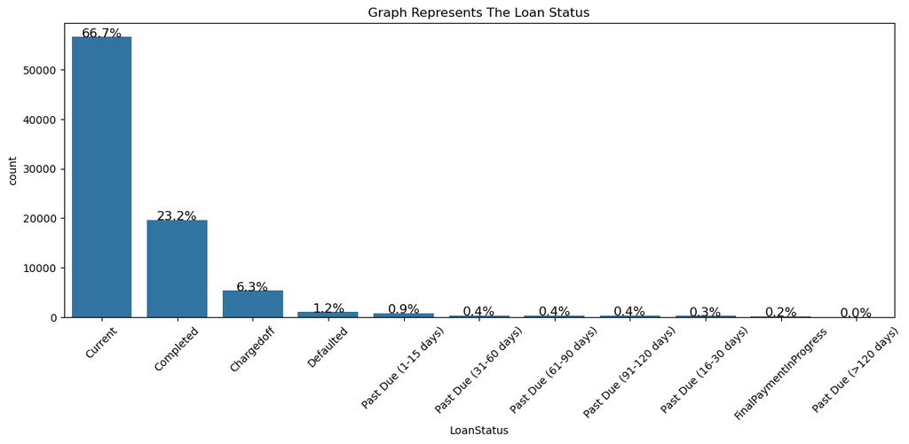

Current loans is the most frequently status with around 66.7%

```
count     84853
unique        3
top          36
freq      58695
Name: Term, dtype: object
```

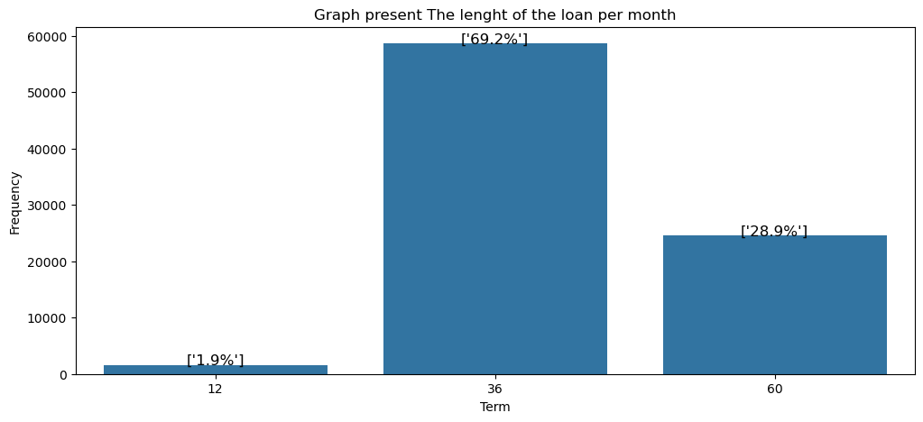

We can notes from this graph that around **69.2%** of people prefare to take a loan with 36 months

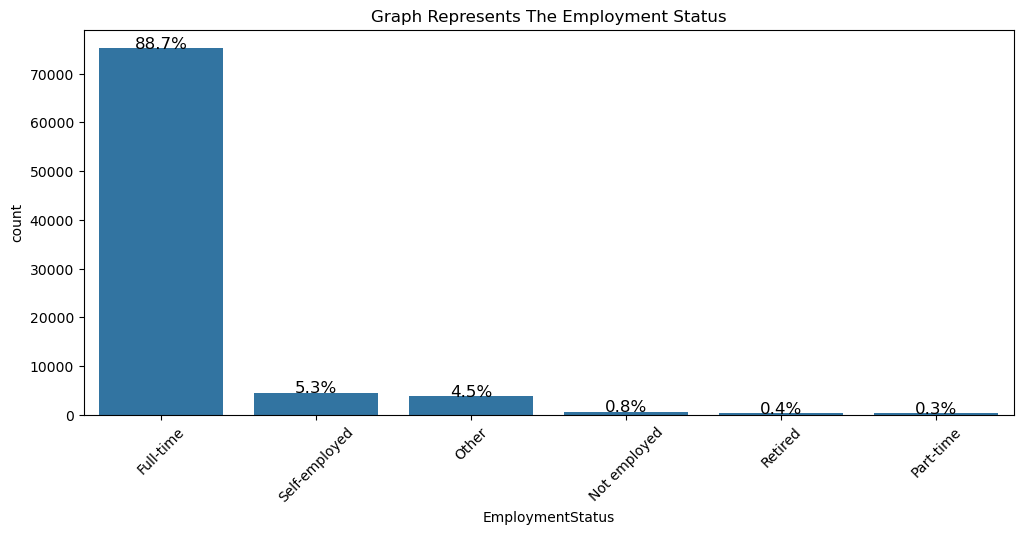

AS we can se from bargraph around **88.7%** have a full time job

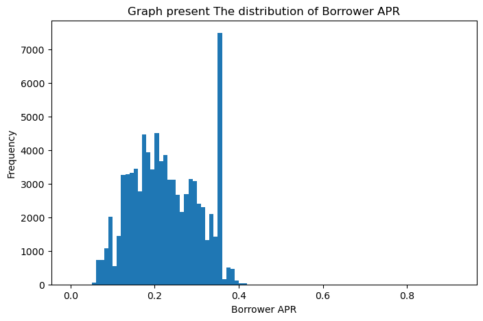

```
count    84853.000000
mean      9083.440515
std       6287.860058
min       1000.000000
25%       4000.000000
50%       7500.000000
75%      13500.000000
max      35000.000000
Name: LoanOriginalAmount, dtype: float64
```

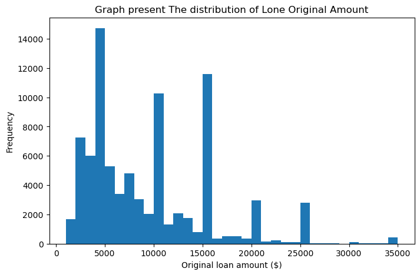

```
Index(['ListingCreationDate', 'Term', 'LoanStatus', 'BorrowerAPR',
       'BorrowerRate', 'ProsperRating (numeric)', 'ProsperRating (Alpha)',
       'Occupation', 'ProsperScore', 'EmploymentStatus',
       'CreditScoreRangeLower', 'CreditScoreRangeUpper', 'IncomeRange',
       'DebtToIncomeRatio', 'LoanOriginalAmount', 'LoanOriginationQuarter',
       'TotalInquiries', 'MonthlyLoanPayment', 'InvestmentFromFriendsCount',
       'InvestmentFromFriendsAmount', 'Investors'],
      dtype='object')
```

```
count    84853.000000
mean       291.930720
std        186.678314
min          0.000000
25%        157.330000
50%        251.940000
75%        388.350000
max       2251.510000
Name: MonthlyLoanPayment, dtype: float64
```

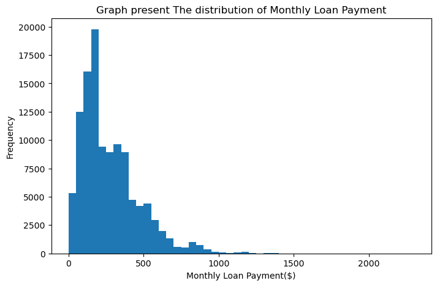

### Discuss the distribution(s) of your variable(s) of interest. Were there any unusual points? Did you need to perform any transformations?

From the distribution grap of the differnt columns the folowing points are generated

### Bivariate Exploration

Befor start with, I want to look at the pairwise correlations present between the dataset's.

```
['ListingCreationDate',
 'Term',
 'LoanStatus',
 'BorrowerAPR',
 'BorrowerRate',
 'ProsperRating (numeric)',
 'ProsperRating (Alpha)',
 'Occupation',
 'ProsperScore',
 'EmploymentStatus',
 'CreditScoreRangeLower',
 'CreditScoreRangeUpper',
 'IncomeRange',
 'DebtToIncomeRatio',
 'LoanOriginalAmount',
 'LoanOriginationQuarter',
 'TotalInquiries',
 'MonthlyLoanPayment',
 'InvestmentFromFriendsCount',
 'InvestmentFromFriendsAmount',
 'Investors']
```

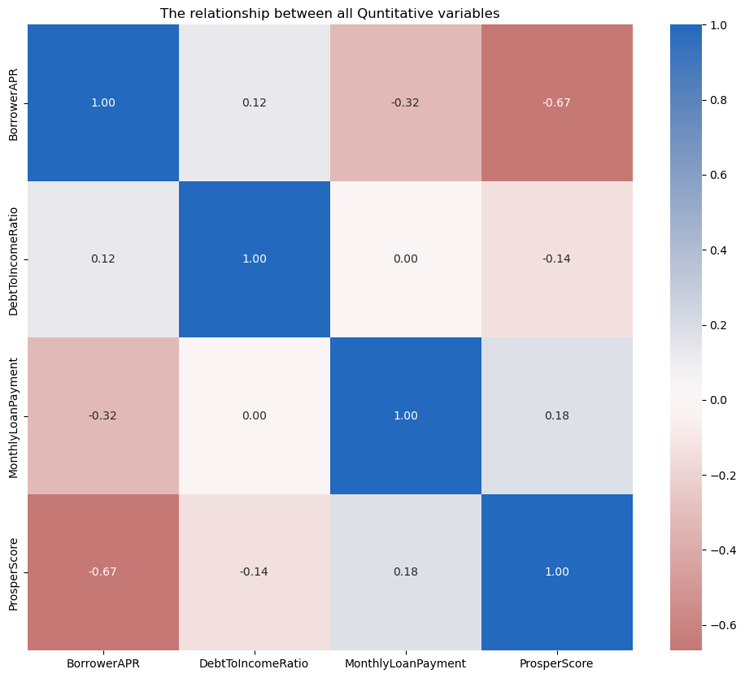

### 1. What factors affects the lone outcome status.

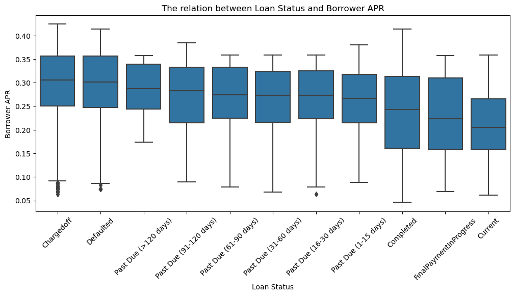

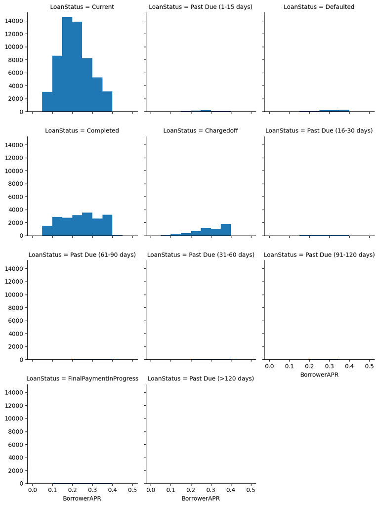

##### Current lone status is the has a highst frequency among the loan status

### 2.What affects the borrower's Annual Percentage Rate (APR) rate.

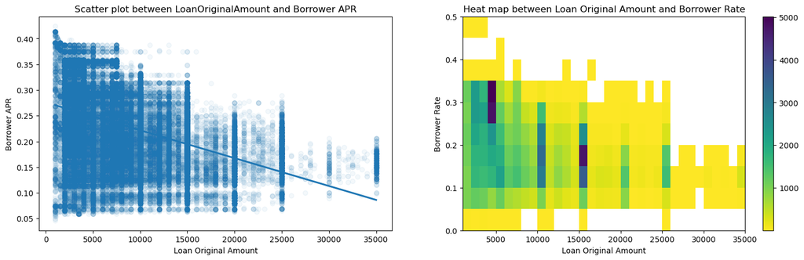

###### As we can see from the two graphs relation between Loan Original Amount and Borrower Rate is negative but not strongly

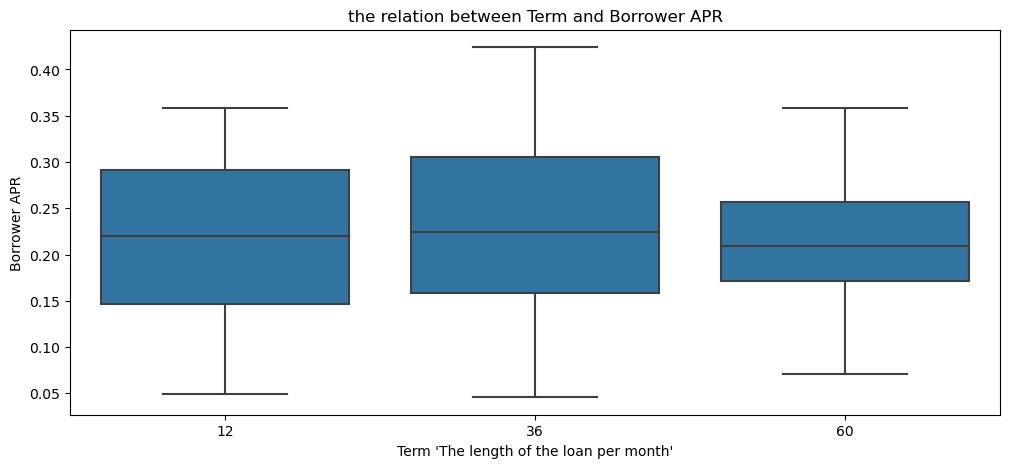

##### The 36 term loan has a wider range of Borrower APR but we need to focus more so we will apply the FacetGrid

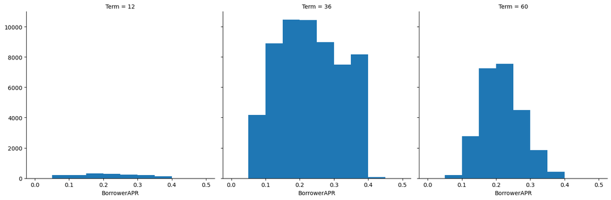

##### In conclusion the 36 months has the wider borrower APR and also has more frequency comparing with 12 & 60 terms

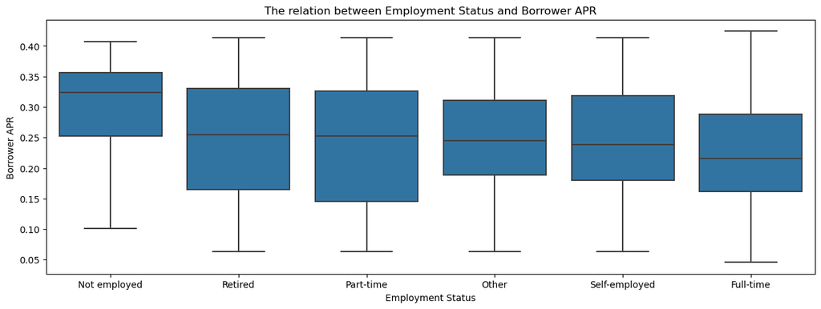

##### From the boxplot Not employed has a highest median and Full-time has the lowest median whre as the part-time has the widest range in the Borrower APR

### Talk about some of the relationships you observed in this part of the investigation. How did the feature(s) of interest vary with other features in the dataset?

The borrower APR is negatively associated with the loan original amount, which mean the more the loan amount, the lower the APR. It also shows that at different size of the loan amount, the APR has a large range, but the range of APR decrease with the increase of loan amount. The Prosper rating also has a strong effect on the borrower APR, which decreases with the better rating.</P>

### Multivariate Exploration

The main thing I want to explore here is,the analysis is how the variable (IncomeRange,EmploymentStatus,Term & LoanStatus) play into the relationship between borrower APR and loan original amount.</P>

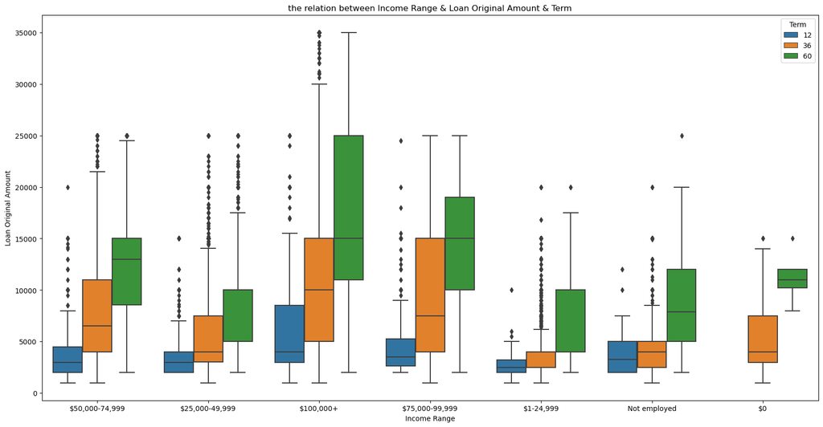

##### It seems very interesting in each IncomeRange when the LoanOriginalAmount increased the medina of 60 Term increase more than 12 & 36 Term medians

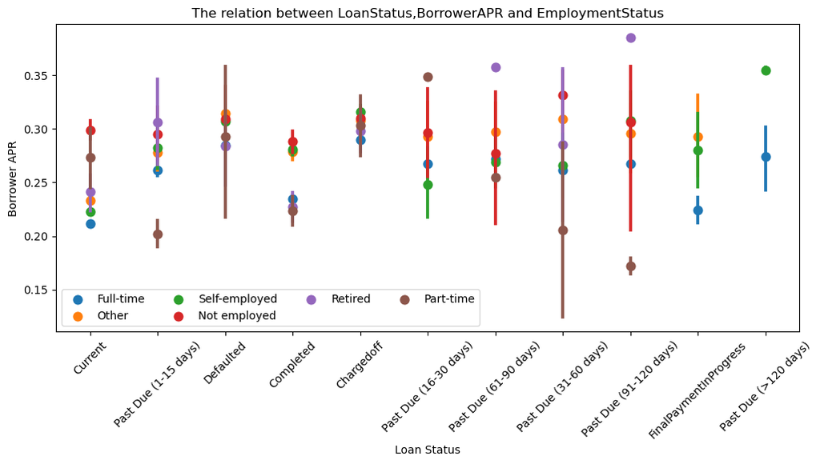

### Were there any interesting or surprising interactions between features?

In each income reange when the loan original amount icreased the medina of 60 months term increase more than 12 and 36 months term medians.